# Веб-аналитика сервиса по продаже билетов

В проекте анализируется поведение пользователей сервиса, осуществляемые ими заказы и приносимый доход, в сопоставлении со способом их привлечения и маркетинговыми затратами.

Цель: сформулировать рекомендации по оптимизации маркетинговых затрат.

### Описание данных

Данные о посещениях сайта, таблица visits

```
* uid — уникальный идентификатор пользователя
* device — категория устройства пользователя
* start_ts — дата и время начала сессии
* end_ts — дата и время окончания сессии
* source_id — идентификатор рекламного источника, из которого пришел пользователь
```

Данные о покупках, таблица orders

```
* uid — уникальный id пользователя, который сделал заказ
* buy_ts — дата и время заказа
* revenue — выручка сервиса с этого заказа
```

Данные о маркетинговых расходах, таблица costs

```
* source_id — идентификатор рекламного источника
* dt — дата
* costs — затраты на этот рекламный источник в этот день
```

### Оглавление

Шаг 1. Подготовка данных.

Выводы по шагу 1.

Шаг 2. Метрики.

2.1. Метрики продукта.

2.2. Метрики продаж.

2.3. Метрики маркетинга.

Summary по шагу. Основные метрики.

Шаг 3. Обший вывод и рекомендации.

```python
import pandas as pd
import numpy as np
import seaborn as sns
import warnings
from matplotlib import pyplot as plt
```

# Шаг 1. Подготовка данных

```python
visits = pd.read_csv('')
orders = pd.read_csv('')
costs = pd.read_csv('')
```

```python
visits.info()
```

```
<class 'pandas.core.frame.DataFrame'>
RangeIndex: 359400 entries, 0 to 359399
Data columns (total 5 columns):
Device       359400 non-null object
End Ts       359400 non-null object
Source Id    359400 non-null int64
Start Ts     359400 non-null object
Uid          359400 non-null uint64
dtypes: int64(1), object(3), uint64(1)
memory usage: 13.7+ MB
```

```python
visits
```

|  | Device | End Ts | Source Id | Start Ts | Uid |
| --- | --- | --- | --- | --- | --- |
| 0 | touch | 2017-12-20 17:38:00 | 4 | 2017-12-20 17:20:00 | 16879256277535980062 |
| 1 | desktop | 2018-02-19 17:21:00 | 2 | 2018-02-19 16:53:00 | 104060357244891740 |
| 2 | touch | 2017-07-01 01:54:00 | 5 | 2017-07-01 01:54:00 | 7459035603376831527 |
| 3 | desktop | 2018-05-20 11:23:00 | 9 | 2018-05-20 10:59:00 | 16174680259334210214 |
| 4 | desktop | 2017-12-27 14:06:00 | 3 | 2017-12-27 14:06:00 | 9969694820036681168 |
| ... | ... | ... | ... | ... | ... |
| 359395 | desktop | 2017-07-29 19:07:19 | 2 | 2017-07-29 19:07:00 | 18363291481961487539 |
| 359396 | touch | 2018-01-25 17:38:19 | 1 | 2018-01-25 17:38:00 | 18370831553019119586 |
| 359397 | desktop | 2018-03-03 10:12:19 | 4 | 2018-03-03 10:12:00 | 18387297585500748294 |
| 359398 | desktop | 2017-11-02 10:12:19 | 5 | 2017-11-02 10:12:00 | 18388616944624776485 |
| 359399 | touch | 2017-09-10 13:13:19 | 2 | 2017-09-10 13:13:00 | 18396128934054549559 |

359400 rows × 5 columns

```python
orders.info()
```

```
<class 'pandas.core.frame.DataFrame'>
RangeIndex: 50415 entries, 0 to 50414
Data columns (total 3 columns):
Buy Ts     50415 non-null object
Revenue    50415 non-null float64
Uid        50415 non-null uint64
dtypes: float64(1), object(1), uint64(1)
memory usage: 1.2+ MB
```

```python
orders
```

|  | Buy Ts | Revenue | Uid |
| --- | --- | --- | --- |
| 0 | 2017-06-01 00:10:00 | 17.00 | 10329302124590727494 |
| 1 | 2017-06-01 00:25:00 | 0.55 | 11627257723692907447 |
| 2 | 2017-06-01 00:27:00 | 0.37 | 17903680561304213844 |
| 3 | 2017-06-01 00:29:00 | 0.55 | 16109239769442553005 |
| 4 | 2017-06-01 07:58:00 | 0.37 | 14200605875248379450 |
| ... | ... | ... | ... |
| 50410 | 2018-05-31 23:50:00 | 4.64 | 12296626599487328624 |
| 50411 | 2018-05-31 23:50:00 | 5.80 | 11369640365507475976 |
| 50412 | 2018-05-31 23:54:00 | 0.30 | 1786462140797698849 |
| 50413 | 2018-05-31 23:56:00 | 3.67 | 3993697860786194247 |
| 50414 | 2018-06-01 00:02:00 | 3.42 | 83872787173869366 |

50415 rows × 3 columns

```python
costs.info()
```

```
<class 'pandas.core.frame.DataFrame'>
RangeIndex: 2542 entries, 0 to 2541
Data columns (total 3 columns):
source_id    2542 non-null int64
dt           2542 non-null object
costs        2542 non-null float64
dtypes: float64(1), int64(1), object(1)
memory usage: 59.7+ KB
```

```python
costs
```

|  | source_id | dt | costs |
| --- | --- | --- | --- |
| 0 | 1 | 2017-06-01 | 75.20 |
| 1 | 1 | 2017-06-02 | 62.25 |
| 2 | 1 | 2017-06-03 | 36.53 |
| 3 | 1 | 2017-06-04 | 55.00 |
| 4 | 1 | 2017-06-05 | 57.08 |
| ... | ... | ... | ... |
| 2537 | 10 | 2018-05-27 | 9.92 |
| 2538 | 10 | 2018-05-28 | 21.26 |
| 2539 | 10 | 2018-05-29 | 11.32 |
| 2540 | 10 | 2018-05-30 | 33.15 |
| 2541 | 10 | 2018-05-31 | 17.60 |

2542 rows × 3 columns

```python
visits.columns = ['device', 'end_ts', 'source_id', 'start_ts', 'uid']
orders.columns = ['buy_ts', 'revenue', 'uid']
costs.columns = ['source_id', 'marketing_date', 'costs']
```

```python
visits['end_ts'] = pd.to_datetime(visits['end_ts'])
visits['start_ts'] = pd.to_datetime(visits['start_ts'])
orders['buy_ts'] = pd.to_datetime(orders['buy_ts'])
costs['marketing_date'] = pd.to_datetime(costs['marketing_date'])
```

```python
costs['payment_month'] = costs['marketing_date'].astype('datetime64[M]')
```

```python
visits['start_ts'].min()
```

```
Timestamp('2017-06-01 00:01:00')
```

```python
visits['start_ts'].max()
```

```
Timestamp('2018-05-31 23:59:00')
```

```python
# Считаем продолжительность сессии в секундах

visits['session_duration'] = (visits['end_ts'] - visits['start_ts']).dt.total_seconds()
```

```python
len(visits.query('session_duration <= 0'))
```

```
35796
```

```python
# Исключаем наблюдения с отрицательной или нулевой продолжительностью сессии.

visits = visits[visits['session_duration'] > 0].reset_index(drop=True)
```

```python
visits['session_date'] = visits['start_ts'].dt.date
visits['session_week'] = visits['start_ts'].dt.week
visits['session_month'] = visits['start_ts'].astype('datetime64[M]')
```

```python
orders['order_date'] = orders['buy_ts'].dt.date
orders['order_week'] = orders['buy_ts'].dt.week
orders['order_month'] = orders['buy_ts'].astype('datetime64[M]')
```

## Выводы по шагу

Были загружены в переменные как датафреймы данные о визитах, заказах и расходах.

Все данные о времени были приведены к типу datetime.

В датафрейме visits была посчитана и добавлена продолжительность каждой сессии. Обнаружилось, что в 35796 из 359400 наблюдений продолжительность сессии меньше либо равна 0 (то есть сессия закончилась не позднее, чем началась). Соответствующие им строки были исключены, так как эти наблюдения, вероятно, следствие ошибки либо технической особенности, которую необходимо прояснить.

# Шаг 2. Метрики

## Метрики продукта

```python
# Функция для отрисовки графиков. На входе три названия колонок из датафрейма visits и строка
# с названием временного периода для оформления графиков: первый аргумент -- что хотим считать,
# количество сессий или количество пользователей (колонки 'start_ts' / 'uid'), второй аргумент --
# категориальная разбивка, на основе которой будем сравнивать подсчитанный показатель ('source_id' / 'device'),
# третий аргумент -- какие временные промежутки будем сравнивать ('session_date' / 'session_week' /
# 'session_month', последний аргумент -- соответствующая третьему строка со словом ('день' / 'неделя' / 'месяц'))

def metric_ill(wut, subj, div, name):
    fig, ax = plt.subplots(figsize=(12,9))
    if wut == 'uid':
        z = visits.groupby([subj, div])[wut].nunique().reset_index()
        sns.barplot(x=subj, y=wut, data=z, capsize=0.05, ax=ax)
        if subj == 'source_id':
            plt.xlabel('Идентификатор рекламного источника')
            plt.ylabel('Уникальных пользователей')
            plt.title('Среднее количество пользователей в '+name)
        if subj == 'device':
            plt.xlabel('Тип устройства')
            plt.ylabel('Уникальных пользователей')
            plt.title('Среднее количество пользователей в '+name)
    if wut == 'start_ts':
        z = visits.groupby([subj, div])[wut].count().reset_index()
        sns.barplot(x=subj, y=wut, data=z, capsize=0.05, ax=ax)
        if subj == 'source_id':
            plt.xlabel('Идентификатор рекламного источника')
            plt.ylabel('Сессий')
            plt.title('Среднее количество сессий в '+name)
        if subj == 'device':
            plt.xlabel('Тип устройства')
            plt.ylabel('Сессий')
            plt.title('Среднее количество сессий в '+name)
    plt.show()
```

### Количество сессий

```python
avg_sessions_per_day = visits.groupby('session_date')['start_ts'].count().mean()
print('Среднее количество сессий в день: {:.0f}'.format(avg_sessions_per_day))
```

```
Среднее количество сессий в день: 889
```

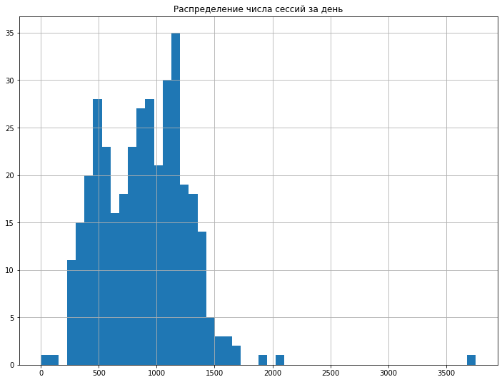

```
count     364.000000
mean      889.021978
std       383.086457
min         1.000000
25%       575.000000
50%       898.000000
75%      1153.750000
max      3755.000000
Name: start_ts, dtype: float64
```

```python
visits.groupby('session_date')['start_ts'].count().hist(figsize=(12,9), bins=50)
plt.title('Распределение числа сессий за день')
plt.show()
visits.groupby('session_date')['start_ts'].count().describe()
```

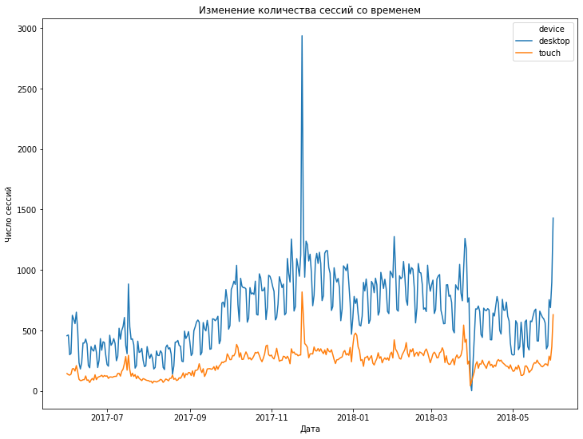

```python
warnings.filterwarnings(action='ignore')
vis = visits.groupby(['device','session_date'])['start_ts'].count().reset_index()
plt.figure(figsize=(12, 9))
sns.lineplot(vis['session_date'], vis['start_ts'], hue=vis['device'])
plt.ylabel('Число сессий')
plt.xlabel('Дата')
plt.title('Изменение количества сессий со временем')
plt.show()
```

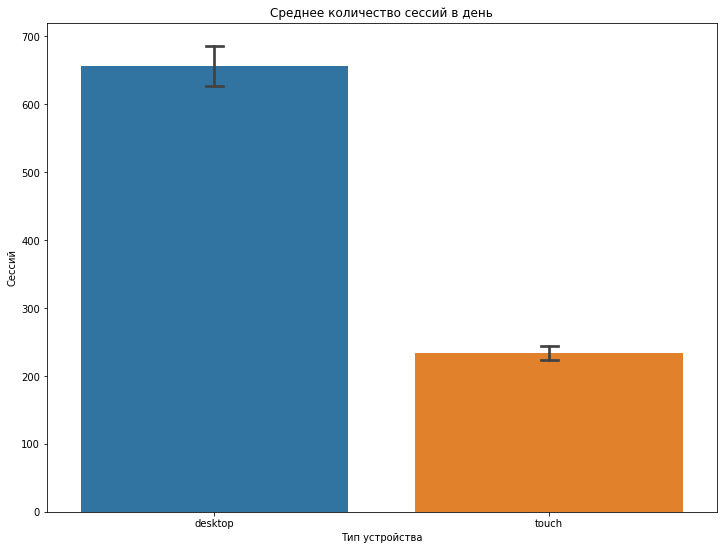

```python
metric_ill('start_ts', 'device', 'session_date', 'день')
```

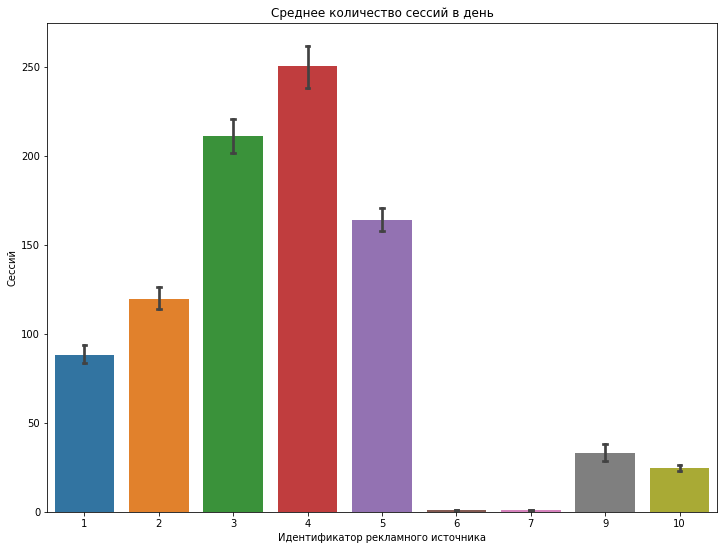

```python
metric_ill('start_ts', 'source_id', 'session_date', 'день')
```

#### Количество сессий: summary

Распределение ежедневного количества сессий бимодально, с пиками в районе 550 и 1150 сессий в день, что характеризует использование сервиса в будние и праздничные/выходные дни. Это же можно увидеть и на периодическом графике изменения количества сессий со временем.

Со стационарных устройств заходят приблизительно в три раза чаще, чем с портативных (~660 и ~230 ежедневных подключений соответственно). Чаще всего пользователи переходят с четвртого рекламного источника.

### Число уникальных пользователей

```python
avg_users_per_day = visits.groupby('session_date')['uid'].nunique().mean()
print('Среднее количество уникальных пользователей в день:', round(avg_users_per_day, 1))
```

```
Среднее количество уникальных пользователей в день: 817.6
```

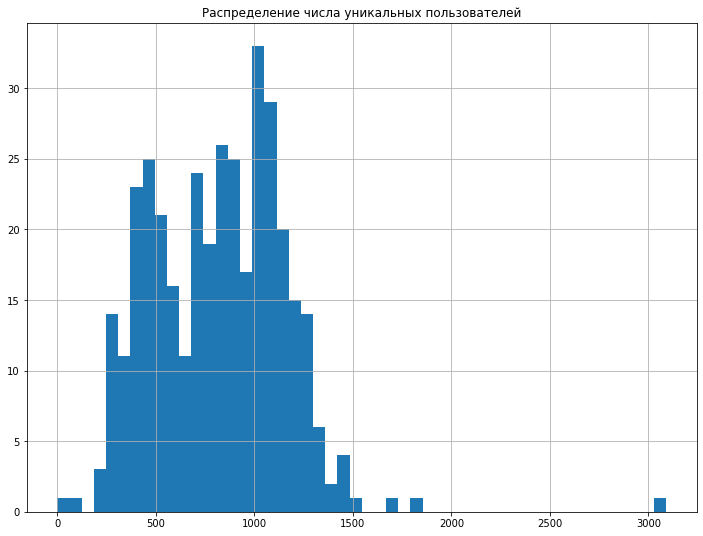

```python
visits.groupby('session_date')['uid'].nunique().hist(figsize=(12,9), bins=50)
plt.title('Распределение числа уникальных пользователей')
plt.show()
```

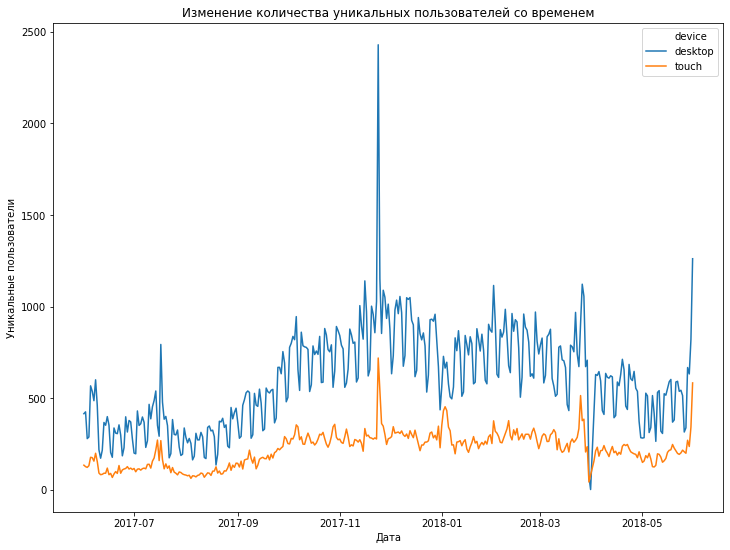

```python
vis = visits.groupby(['device','session_date'])['uid'].nunique().reset_index()
plt.figure(figsize=(12, 9))
sns.lineplot(vis['session_date'], vis['uid'], hue=vis['device'])
plt.ylabel('Уникальные пользователи')
plt.xlabel('Дата')
plt.title('Изменение количества уникальных пользователей со временем')
plt.show()
```

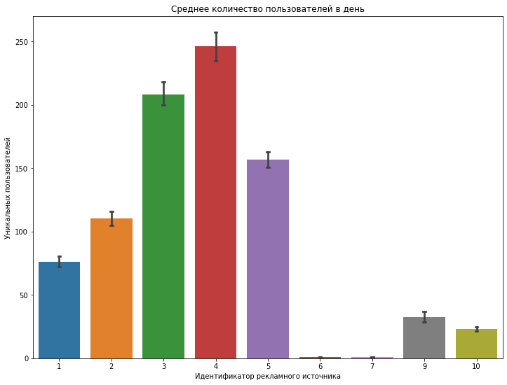

```python
metric_ill('uid', 'source_id', 'session_date', 'день')
```

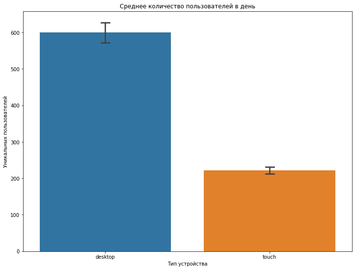

```python
metric_ill('uid', 'device', 'session_date', 'день')
```

```python
users_per_month = visits.groupby('session_month')['uid'].nunique()
avg_users_per_month = users_per_month.mean()

print('Число уникальных пользователей за каждый месяц: \n', users_per_month, end='\n\n')
print('Среднее количество уникальных пользователей в месяц:', round(avg_users_per_month, 1))
```

```
Число уникальных пользователей за каждый месяц:
 session_month
2017-06-01    11885
2017-07-01    12725
2017-08-01    10465
2017-09-01    17117
2017-10-01    26794
2017-11-01    29745
2017-12-01    28593
2018-01-01    25930
2018-02-01    25955
2018-03-01    24872
2018-04-01    18821
2018-05-01    18566
Name: uid, dtype: int64

Среднее количество уникальных пользователей в месяц: 20955.7
```

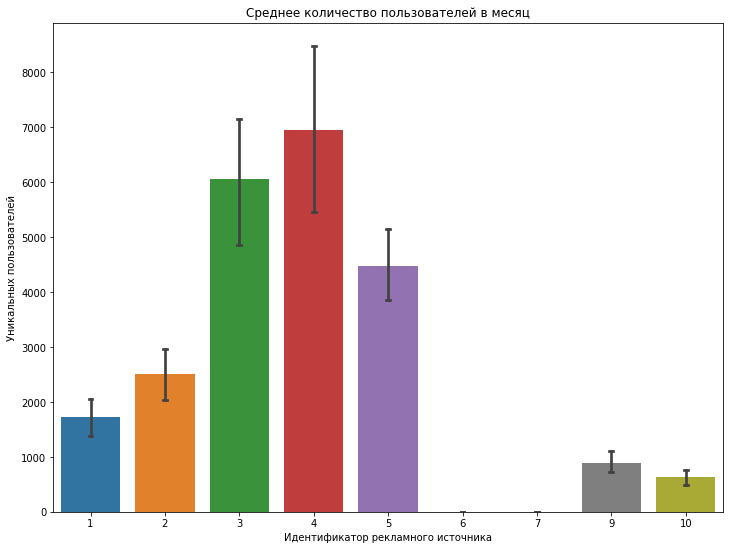

```python
metric_ill('uid', 'source_id', 'session_month', 'месяц')
```

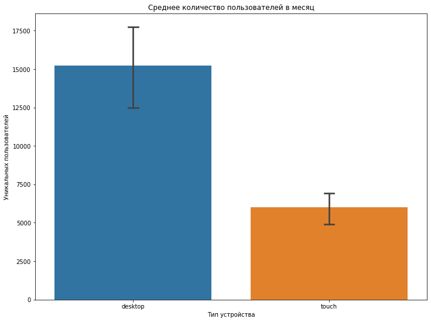

```python
metric_ill('uid', 'device', 'session_month', 'месяц')
```

```python
avg_users_per_week = visits.groupby('session_week')['uid'].nunique().mean()
print('Среднее количество уникальных пользователей в неделю:', round(avg_users_per_week, 1))
```

```
Среднее количество уникальных пользователей в неделю: 5246.5
```

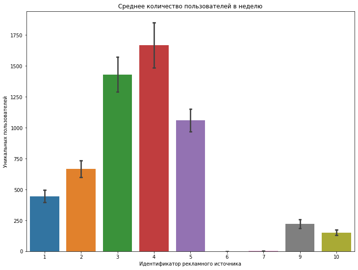

```python
metric_ill('uid', 'source_id', 'session_week', 'неделю')
```

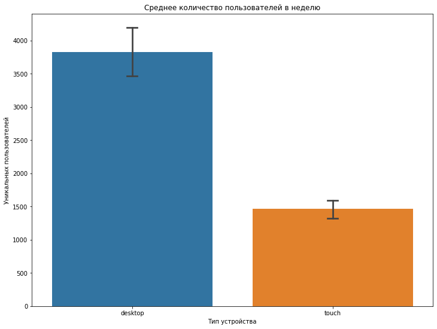

```python
metric_ill('uid', 'device', 'session_week', 'неделю')
```

#### Число уникальных пользователей: summary

Daily Active Users (DAU) = 818. Weekly Active Users (WAU) = 5247. Monthly Active Users (MAU) = 20956.

Больше всего людей пользовались сервисом осенью и в начале зимы: 28.000 - 30.000 пользователей в ноябре и декабре. Меньше всего -- летом (10.000 - 13.000 уникальных пользователей).

Показателей количества уникальных пользователей в день соответствуют измерениям количества сессий, но число пользователей на 10% меньше. Все остальные показатели и закономерности (связанные с разделением по типам устройств и рекламным источнкиам) так же совпадают.

### Продолжительность сессии

```python
# Переводим единицу измерения для продолжительности сессий из секунд в минуты, деля на 60

visits['session_duration'] = visits['session_duration'] / 60
avg_session_duration = visits['session_duration'].mean()
print('Средняя продолжительность сессии составляет {:.1f} минут'.format(avg_session_duration))
```

```
Средняя продолжительность сессии составляет 11.9 минут
```

```python
visits['session_duration'].describe()
```

```
count    323604.000000
mean         11.902825
std          17.105824
min           0.316667
25%           2.000000
50%           6.000000
75%          15.000000
max         711.000000
Name: session_duration, dtype: float64
```

```python
visits['session_duration'].quantile(0.99)
```

```
78.0
```

```python
visits['session_duration'].quantile(0.01)
```

```
1.0000000000000002
```

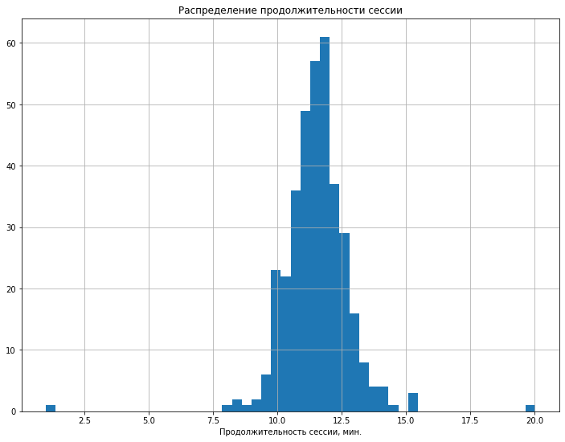

```python
visits.groupby('session_date')['session_duration'].mean().hist(figsize=(12,9), bins=50)
plt.title('Распределение продолжительности сессии')
plt.xlabel('Продолжительность сессии, мин.')
plt.show()
```

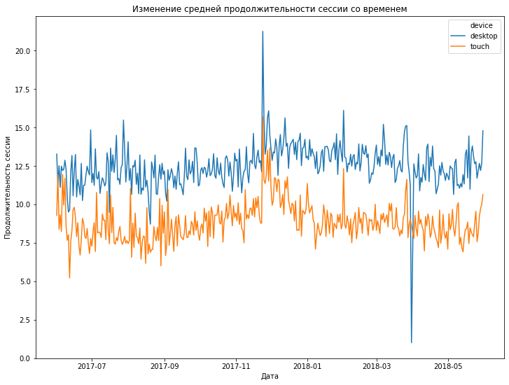

```python
vis = visits.groupby(['device','session_date'])['session_duration'].mean().reset_index()
plt.figure(figsize=(12, 9))
sns.lineplot(vis['session_date'], vis['session_duration'], hue=vis['device'])
plt.ylabel('Продолжительность сессии')
plt.xlabel('Дата')
plt.title('Изменение средней продолжительности сессии со временем')
plt.show()
```

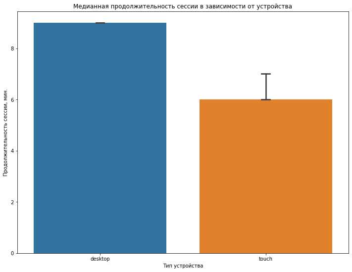

```python
# На графике и в дескрайбе выше нашли день с аномально короткими сессиями на декстопах в конце марта и
# десктопную сессию продолжительностью в 10+ часов. Чтобы они не влияли на дальнейший анализ,
# исключаем их по 1%- и 99%-квантилям (будем рассматривать сессии продолжительностью от 1 до 78 минут)
# кажется, вполне честные границы, характеризующие нормальное бытовое использование подобного сервиса.

z = (visits.loc[(visits['session_duration'] < visits['session_duration'].quantile(0.99)) &
              (visits['session_duration'] > visits['session_duration'].quantile(0.01))])
fig, ax = plt.subplots(figsize=(12,9))
sns.barplot(x='device', y='session_duration', data=z, capsize=0.05, estimator=np.median, order=['desktop', 'touch'])
plt.xlabel('Тип устройства')
plt.ylabel('Продолжительность сессии, мин.')
plt.title('Медианная продолжительность сессии в зависимости от устройства')
plt.show()
```

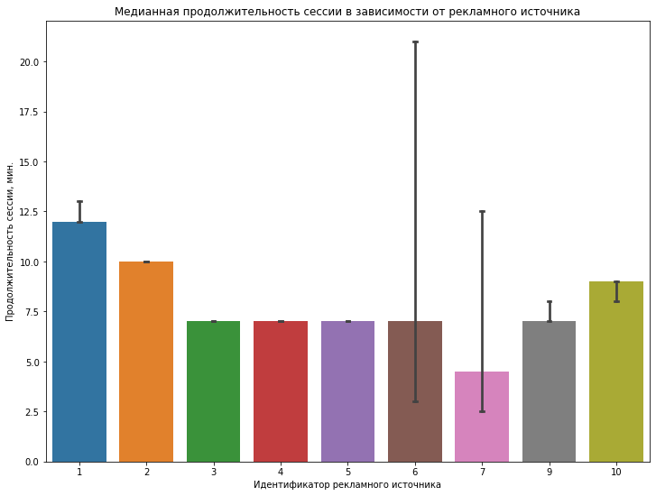

```python
z = (visits.loc[(visits['session_duration'] < visits['session_duration'].quantile(0.99)) &
              (visits['session_duration'] > visits['session_duration'].quantile(0.01))])
fig, ax = plt.subplots(figsize=(12,9))
sns.barplot(x='source_id', y='session_duration', data=z, estimator=np.median, capsize=0.05)
plt.xlabel('Идентификатор рекламного источника')
plt.ylabel('Продолжительность сессии, мин.')
plt.title('Медианная продолжительность сессии в зависимости от рекламного источника')
plt.show()
```

### Коэффициент удержания

```python
number_of_sessions = visits.groupby('uid').agg({'start_ts' : 'count'})
returned_users = len(number_of_sessions.loc[number_of_sessions['start_ts'] > 1]) / len(number_of_sessions)
print('Доля пользователей, заходивших на сайт более одного раза:', round(returned_users, 2))
```

```
Доля пользователей, заходивших на сайт более одного раза: 0.22
```

```python
# Добавляем к каждой строке visits информацию о том, когда соответствующей ей пользователи
# посетил сайт впервые

first_session_date = visits.groupby('uid').agg({'start_ts' : 'min'})
first_session_date.columns = ['first_session_date']
visits = visits.merge(first_session_date, on='uid')
```

```python
# Разделяем пользователей на когорты по месяцу первого посещения

cohorts = first_session_date.copy()
cohorts.columns = ['cohort_by_month']
cohorts['cohort_by_month'] = cohorts['cohort_by_month'].dt.to_period('M')
visits = visits.merge(cohorts, on='uid')
```

```python
visits['first_session_date2'] = visits['first_session_date'].astype('datetime64[M]')
```

```python
visits['lifetime'] = round((visits['session_month'] - visits['first_session_date2']) / np.timedelta64(1, 'M'))
```

```python
raw_retention = visits.pivot_table(index='cohort_by_month', columns = 'lifetime', values='uid', aggfunc='nunique')
```

```python
raw_retention
```

| lifetime cohort_by_month | 0.0 | 1.0 | 2.0 | 3.0 | 4.0 | 5.0 | 6.0 | 7.0 | 8.0 | 9.0 | 10.0 | 11.0 |
| --- | --- | --- | --- | --- | --- | --- | --- | --- | --- | --- | --- | --- |
| 2017-06 | 11885.0 | 900.0 | 606.0 | 710.0 | 777.0 | 802.0 | 686.0 | 667.0 | 606.0 | 591.0 | 453.0 | 522.0 |
| 2017-07 | 11825.0 | 645.0 | 596.0 | 658.0 | 670.0 | 550.0 | 521.0 | 521.0 | 448.0 | 323.0 | 320.0 | NaN |
| 2017-08 | 9214.0 | 686.0 | 557.0 | 557.0 | 442.0 | 382.0 | 334.0 | 347.0 | 250.0 | 228.0 | NaN | NaN |
| 2017-09 | 15125.0 | 1264.0 | 1025.0 | 746.0 | 576.0 | 559.0 | 535.0 | 346.0 | 344.0 | NaN | NaN | NaN |
| 2017-10 | 23538.0 | 1839.0 | 1196.0 | 890.0 | 792.0 | 734.0 | 489.0 | 466.0 | NaN | NaN | NaN | NaN |
| 2017-11 | 24852.0 | 1943.0 | 1062.0 | 940.0 | 810.0 | 540.0 | 512.0 | NaN | NaN | NaN | NaN | NaN |
| 2017-12 | 23030.0 | 1259.0 | 841.0 | 695.0 | 448.0 | 408.0 | NaN | NaN | NaN | NaN | NaN | NaN |
| 2018-01 | 20573.0 | 1189.0 | 778.0 | 501.0 | 396.0 | NaN | NaN | NaN | NaN | NaN | NaN | NaN |
| 2018-02 | 20173.0 | 1141.0 | 490.0 | 387.0 | NaN | NaN | NaN | NaN | NaN | NaN | NaN | NaN |
| 2018-03 | 18793.0 | 766.0 | 480.0 | NaN | NaN | NaN | NaN | NaN | NaN | NaN | NaN | NaN |
| 2018-04 | 14215.0 | 675.0 | NaN | NaN | NaN | NaN | NaN | NaN | NaN | NaN | NaN | NaN |
| 2018-05 | 13828.0 | NaN | NaN | NaN | NaN | NaN | NaN | NaN | NaN | NaN | NaN | NaN |

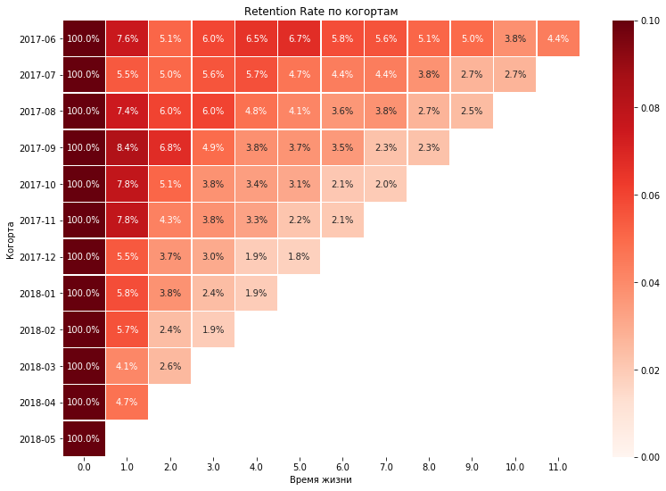

```python
retention_rate_table = raw_retention[:].div(raw_retention[0], axis=0)
plt.figure(figsize=(13, 9))
sns.heatmap(retention_rate_table, cmap='Reds', annot=True, fmt='.1%', vmin = 0.0, vmax = 0.1, linewidths=0.5, linecolor='white')
plt.title('Retention Rate по когортам')
plt.ylabel('Когорта')
plt.xlabel('Время жизни')
plt.show()
```

```python
# Эта и следующая ячейка: каждому пользователю приписываем один рекламный источник
# ('attributed_source', рекламный источник, с которого пользователь попал на сайт впервые)
# и один тип устройства ('attributed_device', тип устройства, с которого пользователь заходит
# на сайт чаще всего), и добавляем эти столбцы в датафреймы visits и orders.

v = visits.groupby(['uid', 'device'])['start_ts'].count().reset_index()
v2 = v.groupby('uid')['start_ts'].max().reset_index()
v = v.merge(v2, on='uid')
device_uid_voc = v.loc[v['start_ts_x'] == v['start_ts_y']][['uid', 'device']]
device_uid_voc.columns = ['uid', 'attributed_device']
orders = orders.merge(device_uid_voc, how='left', on='uid')
visits = visits.merge(device_uid_voc, on='uid')
```

```python
source_attribution = visits.loc[visits['start_ts'] == visits['first_session_date']][['uid', 'source_id']]
source_attribution.columns = ['uid', 'attributed_source']
visits = visits.merge(source_attribution, on='uid')
source_uid_voc = visits.groupby('uid')['attributed_source'].mean().astype('int')
orders = orders.merge(source_uid_voc, how='left', on='uid')
```

```python
retention_by_sources = visits.pivot_table(index='attributed_source', columns='lifetime', values='uid', aggfunc='nunique')
retention_by_sources = retention_by_sources.div(retention_by_sources[0], axis=0)
round(retention_by_sources*100, 1)
```

| lifetime attributed_source | 0.0 | 1.0 | 2.0 | 3.0 | 4.0 | 5.0 | 6.0 | 7.0 | 8.0 | 9.0 | 10.0 | 11.0 |
| --- | --- | --- | --- | --- | --- | --- | --- | --- | --- | --- | --- | --- |
| 1 | 100.0 | 9.8 | 5.7 | 4.3 | 3.5 | 2.8 | 2.4 | 1.8 | 1.4 | 1.0 | 0.8 | 0.6 |
| 2 | 100.0 | 9.3 | 6.1 | 5.2 | 4.5 | 3.6 | 2.8 | 2.3 | 1.6 | 1.2 | 0.9 | 0.6 |
| 3 | 100.0 | 5.8 | 3.7 | 3.0 | 2.4 | 1.8 | 1.5 | 1.1 | 0.8 | 0.5 | 0.3 | 0.2 |
| 4 | 100.0 | 5.4 | 3.2 | 2.6 | 2.0 | 1.7 | 1.2 | 0.9 | 0.6 | 0.4 | 0.3 | 0.2 |
| 5 | 100.0 | 4.3 | 2.6 | 1.9 | 1.5 | 1.3 | 1.0 | 0.7 | 0.5 | 0.3 | 0.2 | 0.1 |
| 6 | 100.0 | NaN | NaN | NaN | NaN | NaN | NaN | NaN | NaN | NaN | NaN | NaN |
| 7 | 100.0 | NaN | 3.2 | 3.2 | NaN | NaN | NaN | NaN | NaN | NaN | NaN | NaN |
| 9 | 100.0 | 11.3 | 8.6 | 6.8 | 5.8 | 4.9 | 3.5 | 2.8 | 2.2 | 1.6 | 1.0 | 0.7 |
| 10 | 100.0 | 5.1 | 2.7 | 1.9 | 1.5 | 1.3 | 1.2 | 0.7 | 0.3 | 0.3 | 0.2 | 0.3 |

```python
retention_by_devices = visits.pivot_table(index='attributed_device', columns='lifetime', values='uid', aggfunc='nunique')
retention_by_devices = retention_by_devices.div(retention_by_devices[0], axis=0)
round(retention_by_devices*100,1)
```

| lifetime attributed_device | 0.0 | 1.0 | 2.0 | 3.0 | 4.0 | 5.0 | 6.0 | 7.0 | 8.0 | 9.0 | 10.0 | 11.0 |
| --- | --- | --- | --- | --- | --- | --- | --- | --- | --- | --- | --- | --- |
| desktop | 100.0 | 6.4 | 4.0 | 3.2 | 2.6 | 2.2 | 1.7 | 1.3 | 0.9 | 0.6 | 0.4 | 0.3 |
| touch | 100.0 | 5.8 | 3.4 | 2.6 | 2.1 | 1.5 | 1.2 | 0.9 | 0.6 | 0.4 | 0.3 | 0.2 |

#### Коэффициент удержания: summary

22% из всех пользователей выборки заходили на сайт более одного раза.

По всем сформированным по первому месяцу посещения когортам наблюдается схожая динамика возвращения пользователей: каждый следующий месяц сайтом пользуются 3-6% людей. При этом коэффициент удержания для когорт 2017 года выше, чем для когорт 2018 года, и в целом чем раньше была сформирована когорта, тем она лояльнее (больше ее членов продолжают дольше пользоваться сервисом). Когорты, сформированные по первому посещению в октябре-декабре, включают вдвое больше пользователей, но и быстрее угасают, чем когорты, сформированные по летним месяцам.

Пользователи десктопов немного лояльнее, чем пользователи портативных устройств.

С наибольшей вероятностью возвращаются пользователи, впервые попавшие на сайт по каналу 9 рекламного источника, несколько уступают в этом показателе 1 и 2 рекламные источники. Самый низкий коэффициент удержания наблюдается для переходов с 5 и 10 рекламных источников.

## Метрики продаж

### Время до первой покупки

```python
# Добавляем в orders информацию о том, когда каждый пользователь совершил свою первую покупку

first_order_date = orders.groupby('uid').agg({'buy_ts' : 'min'})
first_order_date.columns = ['first_order_date']
orders = orders.merge(first_order_date, on='uid')
```

```python
# Добавляем к ранее созданному датафрейму с информация о первом посещении сайта по каждому пользователю

time_to_first_order = first_session_date.merge(first_order_date, on='uid', how='left')
```

```python
proportion_of_buyers = sum(time_to_first_order['first_order_date'].notna()) / len(time_to_first_order)
print('Доля людей, совершивших хотя бы одну покупку, от общего числа пользователей:', round(proportion_of_buyers, 2))
```

```
Доля людей, совершивших хотя бы одну покупку, от общего числа пользователей: 0.17
```

```python
# Считаем время, прошедшее от первого посещения пользователем сайта до его первой покупки

time_to_first_order['time_to_first_purchase'] = (time_to_first_order['first_order_date'] - time_to_first_order['first_session_date']).dt.total_seconds()
```

```python
print(time_to_first_order['time_to_first_purchase'].min())
print(time_to_first_order['time_to_first_purchase'].max() / 3600 / 24)
```

```
-28325760.0
363.2944444444445
```

```python
time_to_first_order['first_order_date'].min()
```

```
Timestamp('2017-06-01 00:10:00')
```

```python
# Обнаруживаем, что 195 пользователей почему-то совершили покупку раньше, чем впервые посетили сайт,
# а еще 2318 человек совершили ее ровно в то же мгновение, когда впервые попали на сайт.
# Возможно, что это какие-то покупки через приложение, но в любом случае это странно.

print(len(time_to_first_order.loc[time_to_first_order['time_to_first_purchase'] == 0]), end='\n\n')
time_to_first_order.loc[time_to_first_order['time_to_first_purchase'] < 0]
```

```
2318
```

| uid | first_session_date | first_order_date | time_to_first_purchase |
| --- | --- | --- | --- |
| 246917802374455080 | 2017-07-17 17:58:00 | 2017-07-15 06:53:00 | -212700.0 |
| 331505068949795458 | 2017-09-14 16:05:00 | 2017-08-25 13:37:00 | -1736880.0 |
| 504121461129059724 | 2018-05-06 15:02:00 | 2018-05-02 09:20:00 | -366120.0 |
| 543499019308129333 | 2018-04-24 15:01:00 | 2018-04-24 10:11:00 | -17400.0 |
| 745110943593938635 | 2018-02-13 18:44:00 | 2018-02-13 18:40:00 | -240.0 |
| ... | ... | ... | ... |
| 17916073670301036411 | 2017-11-29 09:38:00 | 2017-11-24 20:36:00 | -392520.0 |
| 17984178282926323606 | 2018-03-23 20:08:00 | 2018-03-23 20:03:00 | -300.0 |
| 18294232728783843678 | 2017-06-27 11:34:00 | 2017-06-19 10:06:00 | -696480.0 |
| 18347990625682270738 | 2018-04-29 16:53:00 | 2018-03-21 14:31:00 | -3378120.0 |
| 18388230212620033380 | 2018-02-02 22:42:00 | 2017-12-20 00:11:00 | -3882660.0 |

195 rows × 3 columns

```python
# Отбираем строки, в которых первая покупка была совершена позже, чем первое посещение сайта

time_to_first_order_cleared = time_to_first_order.loc[time_to_first_order['time_to_first_purchase'] > 0]
```

```python
# Добавляем данные о времени до первой покупки в orders

orders = orders.merge(time_to_first_order_cleared, on = 'uid', how='left')
```

```python
# Секунды в минуты

orders['time_to_first_purchase'] = orders['time_to_first_purchase'] / 60
```

```python
orders['time_to_first_purchase'].describe()
```

```
count     46826.000000
mean      26463.612395
std       68067.429975
min           1.000000
25%           6.000000
50%          29.000000
75%        7454.000000
max      523144.000000
Name: time_to_first_purchase, dtype: float64
```

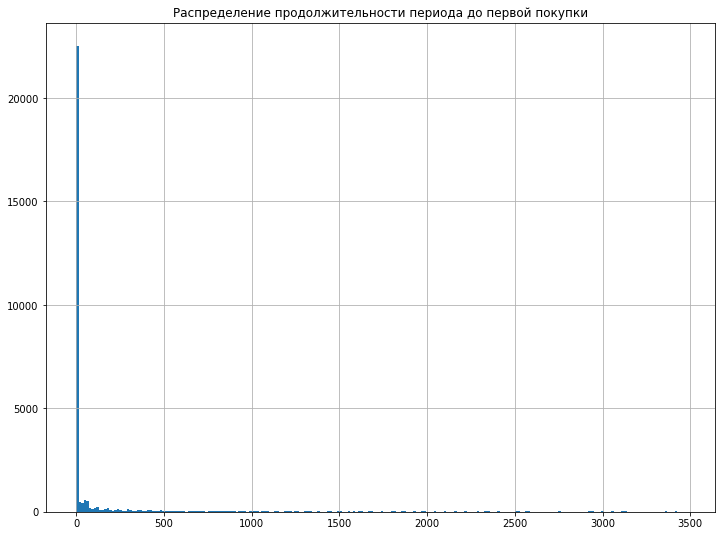

```python
((time_to_first_order_cleared.loc
[time_to_first_order_cleared['time_to_first_purchase'] < time_to_first_order_cleared['time_to_first_purchase'].quantile(0.9)]['time_to_first_purchase'] / 60 / 24)
 .hist(figsize=(12,9), bins=240))
plt.title('Распределение продолжительности периода до первой покупки')
plt.show()
```

```python
avg_time_to_purchase = orders.groupby('uid')['time_to_first_purchase'].mean().mean()/24
print('Среднее количество дней между первым посещением пользователем сайта и его первой покупкой:', round(avg_time_to_purchase, 1))
```

[output not shown]

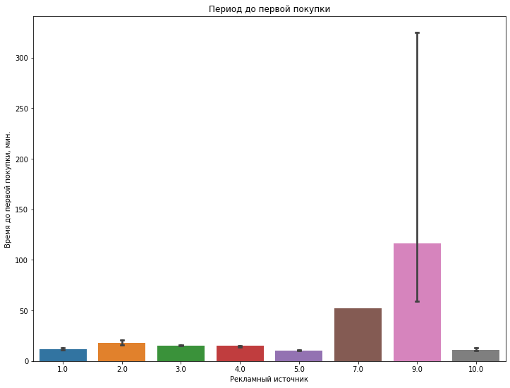

```python
z = (orders.loc[orders['time_to_first_purchase'] < orders['time_to_first_purchase'].quantile(0.9)].
groupby(['uid', 'attributed_source'])['time_to_first_purchase'].median().reset_index())
fig, ax = plt.subplots(figsize=(12, 9))
sns.barplot(x='attributed_source', y='time_to_first_purchase', data=z, estimator = np.median, capsize=0.05, ax=ax)
plt.xlabel('Рекламный источник')
plt.ylabel('Время до первой покупки, мин.')
plt.title('Период до первой покупки')
plt.show()
```

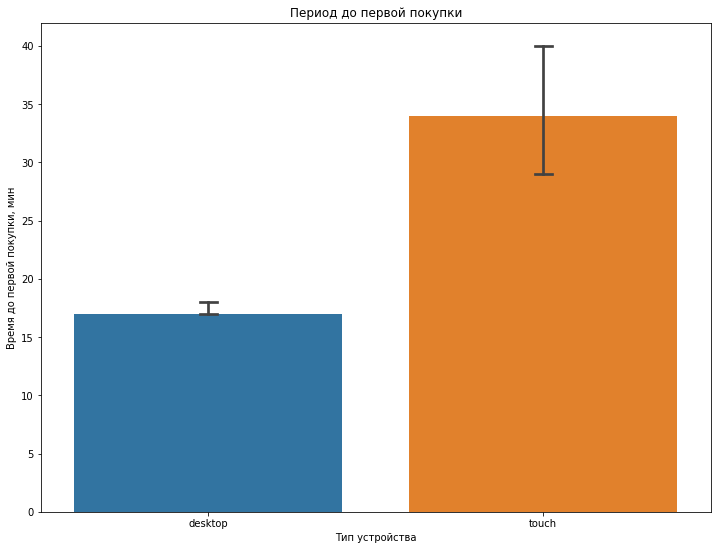

```python
z = orders.groupby(['uid', 'attributed_device'])['time_to_first_purchase'].median().reset_index()
z = z.loc[z['attributed_device'].notna()]
fig, ax = plt.subplots(figsize=(12, 9))
sns.barplot(x='attributed_device', y='time_to_first_purchase', data=z, estimator = np.median, capsize=0.05, ax=ax)
plt.xlabel('Тип устройства')
plt.ylabel('Время до первой покупки, мин')
plt.title('Период до первой покупки')
plt.show()
```

#### Время до первой покупки: summary

Половина всех покупок совершается в течение получаса после первого посещения сайта. Быстрее всего принимают решение о покупке пользователи, перешедшие на сайт с 1, 5 и 10 рекламных источников, медленнее всего -- пользователи, впервые попавшие на сайт с 9 источника.

Медианное время до первой покупки для пользователей портативных устройств значимо больше, чем для пользователей, заходящих на сайт с десктопов.

## Количество покупок

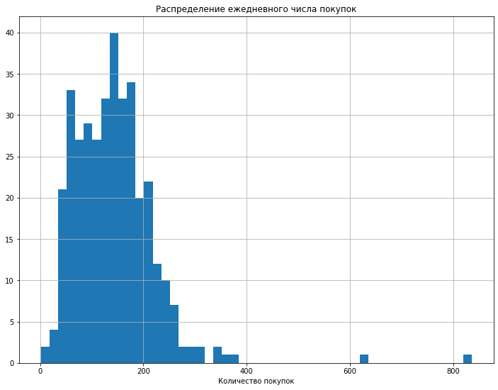

```python
orders.groupby('order_date')['buy_ts'].count().hist(figsize=(12,9), bins=50)
plt.title('Распределение ежедневного числа покупок')
plt.xlabel('Количество покупок')
plt.show()
```

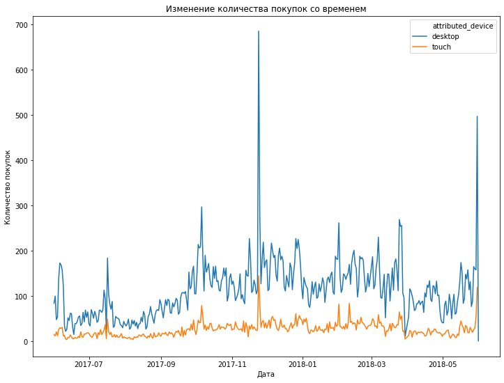

```python
vis = orders.groupby(['attributed_device', 'order_date'])['buy_ts'].count().reset_index()
plt.figure(figsize=(12, 9))
sns.lineplot(vis['order_date'], vis['buy_ts'], hue=vis['attributed_device'])
plt.ylabel('Количество покупок')
plt.xlabel('Дата')
plt.title('Изменение количества покупок со временем')
plt.show()
```

```python
orders_by_day = orders.groupby('order_date')['buy_ts'].count().mean()
print('В среднем за день пользователи делают {:.1f} заказов.'.format(orders_by_day))
```

```
В среднем за день пользователи делают 142.0 заказов.
```

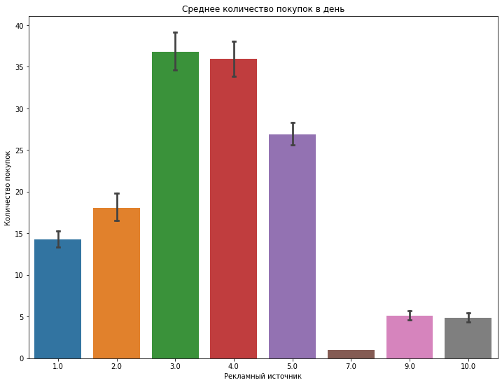

```python
z = orders.groupby(['attributed_source','order_date'])['buy_ts'].count().reset_index()
fig, ax = plt.subplots(figsize=(12,9))
sns.barplot(x='attributed_source', y='buy_ts', data=z, capsize=0.05, ax=ax)
plt.xlabel('Рекламный источник')
plt.ylabel('Количество покупок')
plt.title('Среднее количество покупок в день')
plt.show()
```

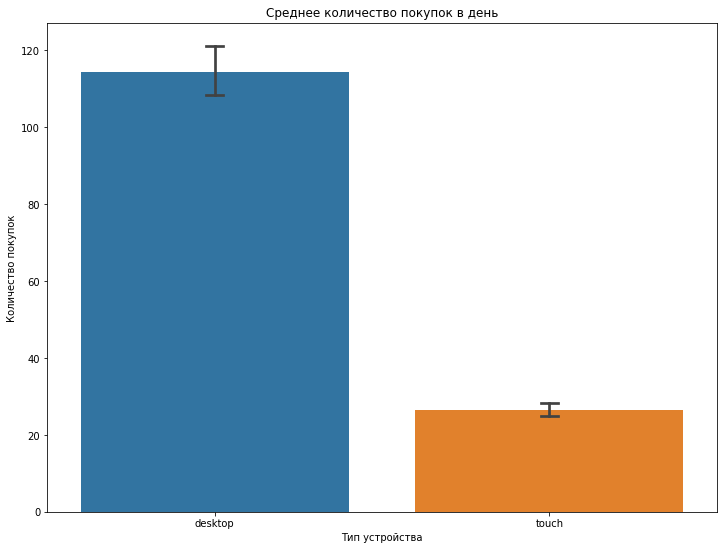

```python
z = orders.groupby(['attributed_device','order_date'])['buy_ts'].count().reset_index()
fig, ax = plt.subplots(figsize=(12,9))
sns.barplot(x='attributed_device', y='buy_ts', data=z, capsize=0.05, ax=ax)
plt.xlabel('Тип устройства')
plt.ylabel('Количество покупок')
plt.title('Среднее количество покупок в день')
plt.show()
```

```python
orders_by_week = orders.groupby('order_week')['buy_ts'].count().mean()
print('В среднем за неделю пользователи делают {:.1f} заказов.'.format(orders_by_week))
```

```
В среднем за неделю пользователи делают 994.2 заказов.
```

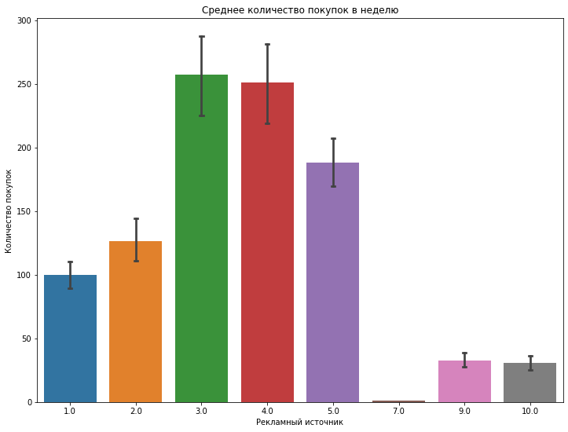

```python
z = orders.groupby(['attributed_source','order_week'])['buy_ts'].count().reset_index()
fig, ax = plt.subplots(figsize=(12,9))
sns.barplot(x='attributed_source', y='buy_ts', data=z, capsize=0.05, ax=ax)
plt.xlabel('Рекламный источник')
plt.ylabel('Количество покупок')
plt.title('Среднее количество покупок в неделю')
plt.show()
```

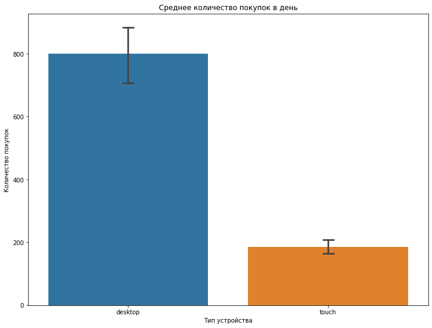

```python
z = orders.groupby(['attributed_device','order_week'])['buy_ts'].count().reset_index()
fig, ax = plt.subplots(figsize=(12,9))
sns.barplot(x='attributed_device', y='buy_ts', data=z, capsize=0.05, ax=ax)
plt.xlabel('Тип устройства')
plt.ylabel('Количество покупок')
plt.title('Среднее количество покупок в день')
plt.show()
```

```python
orders_by_month = orders.groupby('order_month')['buy_ts'].count().mean()
print('В среднем за месяц пользователи делают {:.1f} заказов.'.format(orders_by_month))
```

```
В среднем за месяц пользователи делают 3977.0 заказов.
```

```python
orders.groupby('order_month')['buy_ts'].count()
```

```
order_month
2017-06-01    2432
2017-07-01    2436
2017-08-01    1848
2017-09-01    3463
2017-10-01    5823
2017-11-01    5810
2017-12-01    6392
2018-01-01    4812
2018-02-01    5444
2018-03-01    5463
2018-04-01    3342
2018-05-01    4435
2018-06-01       1
Name: buy_ts, dtype: int64
```

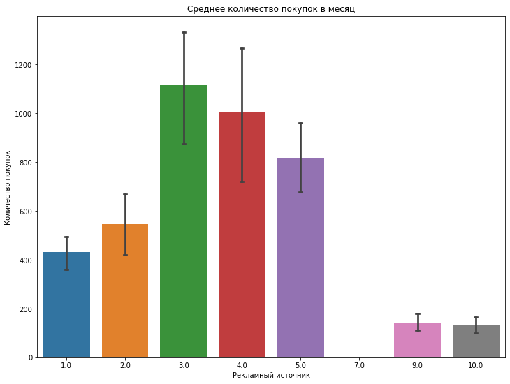

```python
z = orders.groupby(['attributed_source','order_month'])['buy_ts'].count().reset_index()
fig, ax = plt.subplots(figsize=(12,9))
sns.barplot(x='attributed_source', y='buy_ts', data=z, capsize=0.05, ax=ax)
plt.xlabel('Рекламный источник')
plt.ylabel('Количество покупок')
plt.title('Среднее количество покупок в месяц')
plt.show()
```

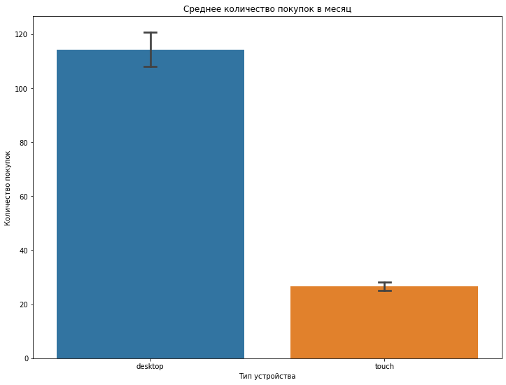

```python
z = orders.groupby(['attributed_device','order_date'])['buy_ts'].count().reset_index()
fig, ax = plt.subplots(figsize=(12,9))
sns.barplot(x='attributed_device', y='buy_ts', data=z, capsize=0.05, ax=ax)
plt.xlabel('Тип устройства')
plt.ylabel('Количество покупок')
plt.title('Среднее количество покупок в месяц')
plt.show()
```

#### Количество покупок: summary

Ситуация с количеством покупок ожидаемо похожая на то, что мы видели в количестве сессий и уникальных пользователей.

Пользователи, впервые попавшие на сайт по каналу третьего, четвертого и пятого рекламных источников, делают значимо больше заказов, чем остальные, а те, кто зашел на сайт с 9 и 10 рекламных источников -- значимо меньше.

```python
orders_sub = orders[['uid', 'buy_ts', 'order_month', 'first_order_date_x']]
```

```python
warnings.filterwarnings(action='ignore')

orders_sub['first_order_date'] = orders_sub['first_order_date_x'].astype('datetime64[M]')
```

```python
warnings.filterwarnings(action='ignore')

orders_sub['age'] = ((orders_sub['order_month'] - orders_sub['first_order_date']) / np.timedelta64(1, 'M')).astype('int')
```

```python
buys_by_cohorts = orders_sub.pivot_table(index='first_order_date', columns='age', values='buy_ts', aggfunc='count')
```

```python
buyers_in_cohorts = orders_sub.groupby('first_order_date')['uid'].nunique()
buyers_in_cohorts
```

```
first_order_date
2017-06-01    2023
2017-07-01    1923
2017-08-01    1370
2017-09-01    2581
2017-10-01    4340
2017-11-01    4081
2017-12-01    4383
2018-01-01    3373
2018-02-01    3651
2018-03-01    3533
2018-04-01    2276
2018-05-01    2988
2018-06-01       1
Name: uid, dtype: int64
```

```python
n_buys = buys_by_cohorts.div(buyers_in_cohorts, axis=0)
n_buys
```

| age first_order_date | 0 | 1 | 2 | 3 | 4 | 5 | 6 | 7 | 8 | 9 | 10 |
| --- | --- | --- | --- | --- | --- | --- | --- | --- | --- | --- | --- |
| 2017-06-01 | 1.291646 | NaN | 0.086505 | 0.111715 | 0.144340 | 0.108255 | 0.137420 | 0.086011 | 0.181908 | 0.047949 | 0.043005 |
| 2017-07-01 | 1.172647 | 0.052522 | 0.062402 | 0.055642 | 0.038482 | 0.043682 | 0.031721 | 0.057202 | NaN | 0.040562 | NaN |
| 2017-08-01 | 1.147445 | 0.083942 | 0.073723 | 0.059124 | 0.062774 | 0.046715 | 0.093431 | 0.033577 | 0.034307 | NaN | NaN |
| 2017-09-01 | 1.249516 | NaN | 0.127083 | NaN | 0.026346 | 0.085626 | 0.022084 | 0.024409 | NaN | NaN | NaN |
| 2017-10-01 | 1.175115 | 0.074424 | 0.038479 | 0.029263 | 0.054839 | 0.019816 | 0.029493 | NaN | NaN | NaN | NaN |
| 2017-11-01 | 1.312914 | NaN | 0.045087 | 0.085763 | 0.014702 | 0.025974 | NaN | NaN | NaN | NaN | NaN |
| 2017-12-01 | 1.187315 | 0.062286 | 0.090121 | 0.020306 | 0.024641 | NaN | NaN | NaN | NaN | NaN | NaN |
| 2018-01-01 | 1.144678 | 0.115921 | 0.019271 | 0.023421 | NaN | NaN | NaN | NaN | NaN | NaN | NaN |
| 2018-02-01 | 1.222679 | 0.023281 | 0.019447 | NaN | NaN | NaN | NaN | NaN | NaN | NaN | NaN |
| 2018-03-01 | 1.200679 | 0.051231 | 0.050099 | NaN | NaN | NaN | NaN | NaN | NaN | NaN | NaN |
| 2018-04-01 | 1.207381 | NaN | NaN | NaN | NaN | NaN | NaN | NaN | NaN | NaN | NaN |
| 2018-05-01 | 1.110776 | NaN | NaN | NaN | NaN | NaN | NaN | NaN | NaN | NaN | NaN |
| 2018-06-01 | 1.000000 | NaN | NaN | NaN | NaN | NaN | NaN | NaN | NaN | NaN | NaN |

```python
# В среднем за первый месяц каждый покупатель делает 1.18 покупок
print('В среднем, покупатель оформляет за первый месяц', round(n_buys[0].mean(), 2), 'заказов')
# При этом мы знаем, что покупает только 17% посетителей, так что в пересчете на посетителей
print('В пересчет на пользователя:', round(n_buys[0].mean() * 0.17, 2))
```

```
В среднем, покупатель оформляет за первый месяц 1.19 заказов
В пересчет на пользователя: 0.2
```

```python
# А вот если считать за полгода использования сервиса, то каждый покупатель делает в среднем
print('За первые полгода использования сервиса, каждый покупатель делает в среднем', round(n_buys.cumsum(axis=1)[5].mean()/6, 2), 'покупок в месяц')
```

```
За первые полгода использования сервиса, каждый покупатель делает в среднем 0.25 покупок в месяц
```

```python
warnings.filterwarnings(action='ignore')

orders_sub['last_date'] = orders_sub['order_month'].max()
```

```python
warnings.filterwarnings(action='ignore')

orders_sub['age2'] = ((orders_sub['last_date'] - orders_sub['first_order_date']) / np.timedelta64(1, 'M')).astype('int')
```

```python
# Считаем для каждого покупателя время жизни, делим на него число совершенных им покупок, в итоге примерно то же самое получили

x1 = orders_sub.groupby('uid')['buy_ts'].count().reset_index()
x2 = orders_sub.groupby('uid')['age2'].max().reset_index()
x3 = x1.merge(x2, on='uid')
x3['age2'] = x3['age2'] + 1
x3['buys_per_month'] = x3['buy_ts'] / x3['age2']
x3['buys_per_month'].mean()
```

```
0.26557399794606484
```

### Средний чек

```python
average_check = orders['revenue'].sum() / len(orders)
print('Средний чек: {:.2f}'.format(average_check))
```

```
Средний чек: 4.98
```

```python
orders['revenue'].describe()
```

```
count    51701.000000
mean         4.975812
std         21.562829
min          0.000000
25%          1.220000
50%          2.440000
75%          4.890000
max       2633.280000
Name: revenue, dtype: float64
```

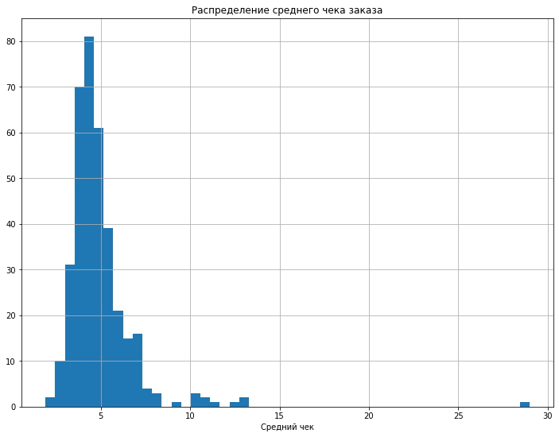

```python
orders.groupby('order_date')['revenue'].mean().hist(figsize=(12,9), bins=50)
plt.title('Распределение среднего чека заказа')
plt.xlabel('Средний чек')
plt.show()
```

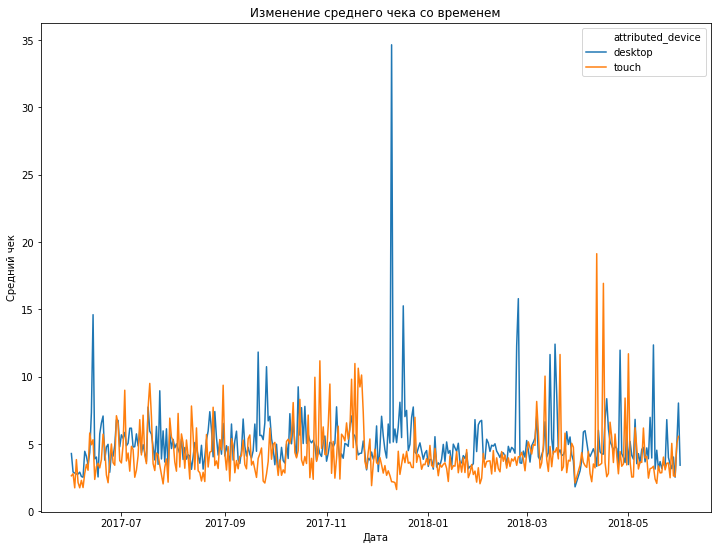

```python
vis = orders.groupby(['attributed_device', 'order_date'])['revenue'].mean().reset_index()
plt.figure(figsize=(12, 9))
sns.lineplot(vis['order_date'], vis['revenue'], hue=vis['attributed_device'])
plt.ylabel('Средний чек')
plt.xlabel('Дата')
plt.title('Изменение среднего чека со временем')
plt.show()
```

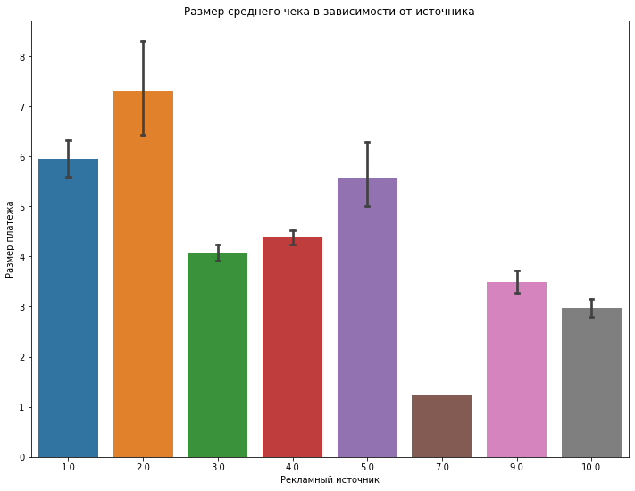

```python
fig, ax = plt.subplots(figsize=(12,9))
sns.barplot(x='attributed_source', y='revenue', data=orders, capsize=0.05, ax=ax)
plt.ylabel('Размер платежа')
plt.xlabel('Рекламный источник')
plt.title('Размер среднего чека в зависимости от источника')
plt.show()
```

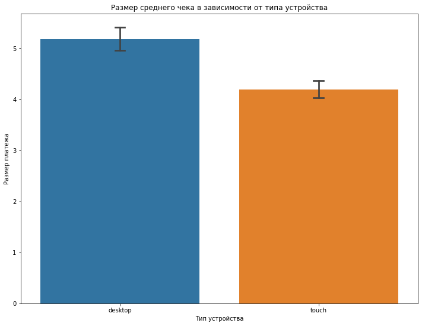

```python
fig, ax = plt.subplots(figsize=(12,9))
sns.barplot(x='attributed_device', y='revenue', data=orders, capsize=0.05, ax=ax)
plt.ylabel('Размер платежа')
plt.xlabel('Тип устройства')
plt.title('Размер среднего чека в зависимости от типа устройства')
plt.show()
```

#### Средний чек: summary

Половина всех покупок приносят от 1.22 до 4.89 у.е. Распределение величины среднего чека с тяжелым правым хвостом, поэтому при среднем в 4.98 условных единиц, медианное значение 2.44 у.е. Чаще всего встречаются заказы на 2-3 у.е.

Величина среднего чека почти не меняется со временем, за исключением отдельных временных повышений, приходящихся, вероятно, на периоды праздников.

Средний чек пользователей, заходящих на сайт с персонального компьютера, приблизительно на 1 у.е. выше. В среднем, самые дорогие заказы оформляют пользователи, впервые попавшие на сайт по каналам 1, 2 и 5 рекламных источников, самые дешевые -- по каналам 9 и 10 рекламных источников.